# pyTarea04

## Tarea04

### Lymh Joshua Morales Chin B54806

### Calculos.py

Dados x=[3,9,20,13,50,89] y y=[20,3,67,80]

1. Construya dos listas x y y en Python con estos valores. En python las listas se construyen utilizando [] como se muestra a continuación:

```python
x=[3,9,20,13,50,89]
y=[20,3,67,80]
```

1. Usando las bibliotecas vistas en clase calcular para ambas listas: la media, la desviación estándar y la mediana

Para el cálculo de la media, la desviación estándar y la mediana se importó la biblioteca statistics, esta biblioteca contiene las funciones mencionadas y se implementa de la siguiente manera:

```python
import statistics as stats

x=[3,9,20,13,50,89]
y=[20,3,67,80]

print("Mean:",stats.mean(x))
print("Standar deviation:",stats.pstdev(x))
print("Median:",stats.median(x))
```

```
Mean: 30.666666666666668
Standar deviation: 30.103525079668366
Median: 16.5
```

Ahora para y:

```python
print("Mean:",stats.mean(y))
print("Standar deviation:",stats.pstdev(y))
print("Median:",stats.median(y))
```

```
Mean: 42.5
Standar deviation: 31.9100297712177
Median: 43.5
```

## Tablas.py

1. Construir una tabla con pandas que contiene:

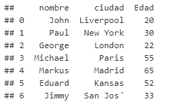

Para construir la tabla anterior, se importó la biblioteca de pandas que contiene el método pd.DataFrame. Para crear un DataFrame cada fila debe contener la misma cantidad de columnas y se implementa de la siguiente manera:

```python
import pandas as pd
from numpy import mean, std
import numpy as np

datos = {'nombre': ["John","Paul","George","Michael","Markus","Eduard","Jimmy"],
         'ciudad': ["Liverpool","New York","London","Paris","Madrid","Kansas","San Jose"],
         'Edad': [20,30,22,55,65,52,33]
         }

table_pandas = pd.DataFrame(datos)
print("\n",table_pandas)
```

```
     nombre     ciudad  Edad
0     John  Liverpool    20
1     Paul   New York    30
2   George     London    22
3  Michael      Paris    55
4   Markus     Madrid    65
5   Eduard     Kansas    52
6    Jimmy   San Jose    33
```

1. Calcular la media y la desviación estándar de la columna de edad.

Para realizar esta tarea se usa el método loc de pandas, ya que permite seleccionar filas o columnas en base a una etiqueta. Y para calcular la media y la desviación estándar se usa la biblioteca numpy.

```python
print("Median:",mean(table_pandas.loc[:,'Edad']))
print("Standar deviation:",std(table_pandas.loc[:,'Edad']))
```

```
Median: 39.57142857142857
Standar deviation: 16.325765288184748
```

1. Ordenar la tabla por nombre (ascendente)

Para ordenar la tabla por nombre se usa el método sort_value que solicita la etiqueta (columna que se desea ordenar) y si se quiere de forma ascendente, como se muestra a continuación:

```python
print("\n",table_pandas.sort_values(by=['nombre'],ascending=[True]))
```

```
     nombre     ciudad  Edad
5   Eduard     Kansas    52
2   George     London    22
6    Jimmy   San Jose    33
0     John  Liverpool    20
4   Markus     Madrid    65
3  Michael      Paris    55
1     Paul   New York    30
```

Y de forma descendente por cuidad:

```python
print("\n",table_pandas.sort_values(by=['ciudad'],ascending=[False]))
```

```
     nombre     ciudad  Edad
6    Jimmy   San Jose    33
3  Michael      Paris    55
1     Paul   New York    30
4   Markus     Madrid    65
2   George     London    22
0     John  Liverpool    20
5   Eduard     Kansas    52
```

## Operaciones.py

Escriba en Python para que dado la lista = (-9,-45,0,7,45,-100,89)

1. Calcule la suma de los números positivos.
2. Calcular la suma de los números negativos en valor absoluto
3. Ordenar la lista en forma ascendente

1) Para calcular la suma de numeros positivos se creo la lista en python, luego se implemto un for que recorriera la longitud de la lista y un if para solo sumar los numeros mayores a 0.

```python
from numpy import mean, std


operaciones_lista=[-9,-45,0,7,45,-100,89]
suma_numeros_positivos=0
suma_numero_negativos=0

for i in range(len(operaciones_lista)):
    if operaciones_lista[i]>=0:
        suma_numeros_positivos+=operaciones_lista[i]

print("Suma de numeros positivos:",suma_numeros_positivos)
```

```
Suma de numeros positivos: 141
```

2) Para la suma de numeros negativos se uso la misma logica anterior con la excepcion que se utizo el metodo abs.

```python
for i in range(len(operaciones_lista)):
    if operaciones_lista[i]<=0:
        suma_numero_negativos+=abs(operaciones_lista[i])

print("Suma de numeros negativos",suma_numero_negativos)
```

```
Suma de numeros negativos 154
```

3) Para ordenar la lista de manera ascendente se utilizo el metodo sorted que lo que hace es devolver la lista en orden especifico.

```python
print(sorted(operaciones_lista))
```

```
[-100, -45, -9, 0, 7, 45, 89]
```

## ExplocarionCovid.py

1) Deben hacer una funcion CargarArchivo que permite cargar el archivo con pandas y leerlo a memoria con estos detalles:

1.1) El archivo a leer es: time_series_covid19_confirmed_global.csv

Con la biblioteca os podemos ver el directorio en que nos encontramos actualmente. Con la biblioteca pandas se puede leer el archivo "time_series_covid19_confirmed_global.csv"

```python
import pandas as pd
import numpy as np
import statistics as stats
import os
import matplotlib.pyplot as plt

directorio_actual=os.getcwd()
print(directorio_actual)

def set_Data(archivo_csv):
    datos_est = pd.read_csv(archivo_csv)
    return pd.DataFrame(datos_est)

CovidConfirmados=set_Data('./time_series_covid19_confirmed_global.csv')
print(CovidConfirmados)
```

```
C:\Users\Lymh
    Province/State      Country/Region        Lat        Long  1/22/20  \
0              NaN         Afghanistan  33.939110   67.709953        0
1              NaN             Albania  41.153300   20.168300        0
2              NaN             Algeria  28.033900    1.659600        0
3              NaN             Andorra  42.506300    1.521800        0
4              NaN              Angola -11.202700   17.873900        0
..             ...                 ...        ...         ...      ...
268            NaN             Vietnam  14.058324  108.277199        0
269            NaN  West Bank and Gaza  31.952200   35.233200        0
270            NaN               Yemen  15.552727   48.516388        0
271            NaN              Zambia -13.133897   27.849332        0
272            NaN            Zimbabwe -19.015438   29.154857        0

     1/23/20  1/24/20  1/25/20  1/26/20  1/27/20  ...  1/28/21  1/29/21  \
```

[output cut: 26 more lines]

2)Deben eliminar la primera columna con el nombre "Provincia/State"

2.1) Deben eliminar la columna “Lat” y “Long” de la tabla.

Para eliminar la columna "Provincia/State", “Lat” y “Long” se llamó al método drop, ya que drop remueve filas o columnas especificando la etiqueta de la siguiente manera:

```python
def delete_column(datosFrame):

    newDataFrame=datosFrame.drop(['Province/State','Lat','Long'],axis=1)
    return newDataFrame

CovidConfirmados_Nuevo=delete_column(CovidConfirmados)
print(CovidConfirmados_Nuevo)
```

```
         Country/Region  1/22/20  1/23/20  1/24/20  1/25/20  1/26/20  1/27/20  \
0           Afghanistan        0        0        0        0        0        0
1               Albania        0        0        0        0        0        0
2               Algeria        0        0        0        0        0        0
3               Andorra        0        0        0        0        0        0
4                Angola        0        0        0        0        0        0
..                  ...      ...      ...      ...      ...      ...      ...
268             Vietnam        0        2        2        2        2        2
269  West Bank and Gaza        0        0        0        0        0        0
270               Yemen        0        0        0        0        0        0
271              Zambia        0        0        0        0        0        0
272            Zimbabwe        0        0        0        0        0        0

     1/28/20  1/29/20  1/30/20  ...  1/28/21  1/29/21  1/30/21  1/31/21  \
0          0        0        0  ...    54891    54939    55008    55023
```

[output cut: 25 more lines]

3) Escriba una función que recibe una lista con estos nombres y devuelven un data frame con solamente estos países para todas las fechas contenidas en el archivo original

“Costa Rica”, “Panama”, “Colombia” “Spain”, “Italy”, “Mexico” y “Germany”

Para realizar se uso el metodo set_index para pasar country/Region como primera columna, posteriormente se utilizo el metodo loc que busca por etiqueta las columnas del frame.

```python
def set_index(dataframe):
    newDataFrame_index=dataframe.set_index('Country/Region')
    newDataFrame_index2=newDataFrame_index.loc[['Costa Rica', 'Panama', 'Colombia', 'Spain', 'Italy', 'Mexico', 'Germany']]
    return newDataFrame_index2

CovidConfirmados_Nuevo2=set_index(CovidConfirmados_Nuevo)
print(CovidConfirmados_Nuevo2)
```

```
                1/22/20  1/23/20  1/24/20  1/25/20  1/26/20  1/27/20  1/28/20  \
Country/Region
Costa Rica            0        0        0        0        0        0        0
Panama                0        0        0        0        0        0        0
Colombia              0        0        0        0        0        0        0
Spain                 0        0        0        0        0        0        0
Italy                 0        0        0        0        0        0        0
Mexico                0        0        0        0        0        0        0
Germany               0        0        0        0        0        1        4

                1/29/20  1/30/20  1/31/20  ...  1/28/21  1/29/21  1/30/21  \
Country/Region                             ...
Costa Rica            0        0        0  ...   192637   193276   193276
Panama                0        0        0  ...   316808   318253   319453
Colombia              0        0        0  ...  2067575  2077633  2086806
Spain                 0        0        0  ...  2705001  2743119  2743119
Italy                 0        0        2  ...  2515507  2529070  2541783
Mexico                0        0        0  ...  1825519  1841893  1857230
Germany               4        4        5  ...  2194562  2207393  2224911

                1/31/21   2/1/21   2/2/21   2/3/21   2/4/21   2/5/21   2/6/21
Country/Region
Costa Rica       193276   194569   195009   195537   195992   196438   196438
Panama           320379   321103   322201   323382   324489   325487   326464
Colombia        2094884  2104506  2114597  2125622  2135412  2142660  2151207
Spain           2743119  2822805  2851869  2883465  2913425  2941990  2941990
Italy           2553032  2560957  2570608  2583790  2597446  2611659  2625098
Mexico          1864260  1869708  1874092  1886245  1886245  1912871  1926080
Germany         2225659  2232327  2240017  2252504  2265536  2276371  2285003

[7 rows x 382 columns]
```

Y por último, se grafica los datos de los países seleccionados usando iloc que lee por posición.

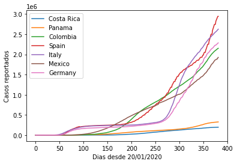

```
None
```

```python
def plotFrame(dataFrame):
    x = np.linspace(0, 381, 381)
    plt.plot(x,dataFrame.iloc[0,1:382])
    plt.plot(x,dataFrame.iloc[1,1:382])
    plt.plot(x,dataFrame.iloc[2,1:382])
    plt.plot(x,dataFrame.iloc[3,1:382])
    plt.plot(x,dataFrame.iloc[4,1:382])
    plt.plot(x,dataFrame.iloc[5,1:382])
    plt.plot(x,dataFrame.iloc[6,1:382])
    plt.legend(['Costa Rica', 'Panama', 'Colombia', 'Spain', 'Italy', 'Mexico', 'Germany'])
    plt.xlabel('Dias desde 20/01/2020')
    plt.ylabel('Casos reportados')
    plt.show()

CovidConfirmados_Nuevo3=plotFrame(CovidConfirmados_Nuevo2)
print(CovidConfirmados_Nuevo3)
```

Una vez explicado lo anterior, se crea un codigo para poder imprimir varios archivos cvs llamando las funciones de la siguiente manera:

```
C:\Users\Lymh
```

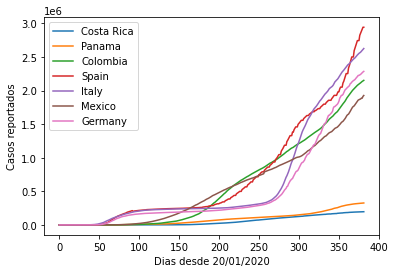

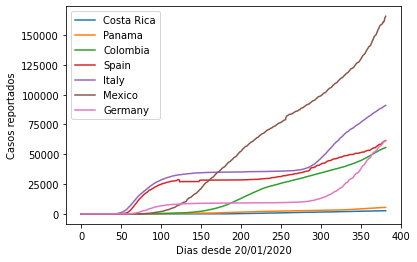

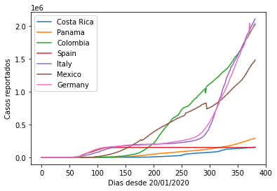

```python
import pandas as pd
from numpy import mean, std
import numpy as np
import statistics as stats
import os
import matplotlib.pyplot as plt

directorio_actual=os.getcwd()
print(directorio_actual)


def set_Data(archivo_csv):
    datos_est = pd.read_csv(archivo_csv)
    return pd.DataFrame(datos_est)

def delete_column(datosFrame):

    newDataFrame=datosFrame.drop(['Province/State','Lat','Long'],axis=1)
    return newDataFrame

def set_index(dataframe):
    newDataFrame_index=dataframe.set_index('Country/Region')
    newDataFrame_index2=newDataFrame_index.loc[['Costa Rica', 'Panama', 'Colombia', 'Spain', 'Italy', 'Mexico', 'Germany']]
    return newDataFrame_index2


def plotFrame(dataFrame):
    x = np.linspace(0, 381, 381)
    plt.plot(x,dataFrame.iloc[0,1:382])
    plt.plot(x,dataFrame.iloc[1,1:382])
    plt.plot(x,dataFrame.iloc[2,1:382])
    plt.plot(x,dataFrame.iloc[3,1:382])
    plt.plot(x,dataFrame.iloc[4,1:382])
    plt.plot(x,dataFrame.iloc[5,1:382])
    plt.plot(x,dataFrame.iloc[6,1:382])
    plt.legend(['Costa Rica', 'Panama', 'Colombia', 'Spain', 'Italy', 'Mexico', 'Germany'])
    plt.xlabel('Dias desde 20/01/2020')
    plt.ylabel('Casos reportados')
    plt.show()


def Analice_Dato(archivo_csv):
    Frame=set_Data(archivo_csv)
    Frame=delete_column(Frame)
    Frame=set_index(Frame)
    plotFrame(Frame)

Analice_Dato('./time_series_covid19_confirmed_global.csv')
Analice_Dato('./time_series_covid19_deaths_global.csv')
Analice_Dato('./time_series_covid19_recovered_global.csv')
```